# Santé et démographie dans les Pays de la Loire

Indicateurs départementaux d’espérance de vie, de mortalité, de vieillissement et d’accès aux médecins généralistes

Auteur·rice

Guy Darcy Remesha

Date de publication

24 octobre 2026

**NoteÀ propos de ce document**

Ce rapport est un projet personnel, réalisé à partir de **données publiques de l’Insee et de la DREES**. Il illustre une chaîne de production complète et reproductible : import des fichiers sources, stockage dans une base **SQLite**, calcul des indicateurs en **SQL**, puis restitution automatisée en **Quarto** (tableaux, graphiques, cartes). Une application **Shiny** permet d’explorer les mêmes données de façon interactive. Le code est disponible sur GitHub.

# 1 Les Pays de la Loire en chiffres clés

**Voir le code**

```r
synthese <- requete("01_tableau_synthese.sql", annee = annee_ref)
region   <- filter(synthese, code == "52")
france   <- filter(synthese, code == "FR")
deps     <- filter(synthese, niveau == "departement")
```

Au 1<sup>er</sup> janvier 2024, les Pays de la Loire comptent **3 926 871 habitants**. L’espérance de vie à la naissance y atteint **86,2 ans pour les femmes** et **80,5 ans pour les hommes**, contre respectivement 85,8 et 80,2 ans en France.

**Voir le code**

```r
synthese |>
  transmute(
    Territoire = libelle,
    Population = fmtn(pop_total),
    `Part des 75 ans ou plus (%)` = fmt(part_75_plus_pct),
    `Taux brut de mortalité (‰)` = fmt(taux_mortalite_pm),
    `Espérance de vie femmes (ans)` = fmt(esp_vie_femmes),
    `Rang national femmes` = ifelse(is.na(rang_ev_femmes), "",
                                    paste0(rang_ev_femmes, "/", nb_departements)),
    `Espérance de vie hommes (ans)` = fmt(esp_vie_hommes),
    `Rang national hommes` = ifelse(is.na(rang_ev_hommes), "",
                                    paste0(rang_ev_hommes, "/", nb_departements))
  ) |>
  kable(align = "lrrrrrrr")
```

Tableau 1: Principaux indicateurs en 2024

| Territoire | Population | Part des 75 ans ou plus (%) | Taux brut de mortalité (‰) | Espérance de vie femmes (ans) | Rang national femmes | Espérance de vie hommes (ans) | Rang national hommes |
| --- | --- | --- | --- | --- | --- | --- | --- |
| Loire-Atlantique | 1 499 333 | 9,4 | 8,3 | 86,3 | 16/101 | 80,4 | 33/101 |
| Maine-et-Loire | 837 086 | 10,7 | 8,9 | 86,7 | 7/101 | 81,5 | 12/101 |
| Mayenne | 304 794 | 11,7 | 10,6 | 86,4 | 13/101 | 80,4 | 33/101 |
| Sarthe | 566 239 | 11,6 | 10,6 | 85,7 | 31/101 | 79,6 | 54/101 |
| Vendée | 719 419 | 12,6 | 11,3 | 85,5 | 45/101 | 80,2 | 40/101 |
| Pays de la Loire | 3 926 871 | 10,8 | 9,5 | 86,2 |  | 80,5 |  |
| France | 68 638 377 | 10,4 | 9,3 | 85,8 |  | 80,2 |  |

*Lecture : le rang national classe les départements français de l’espérance de vie la plus élevée (rang 1) à la plus faible.*

# 2 Espérance de vie à la naissance

## 2.1 Écarts entre départements

**Voir le code**

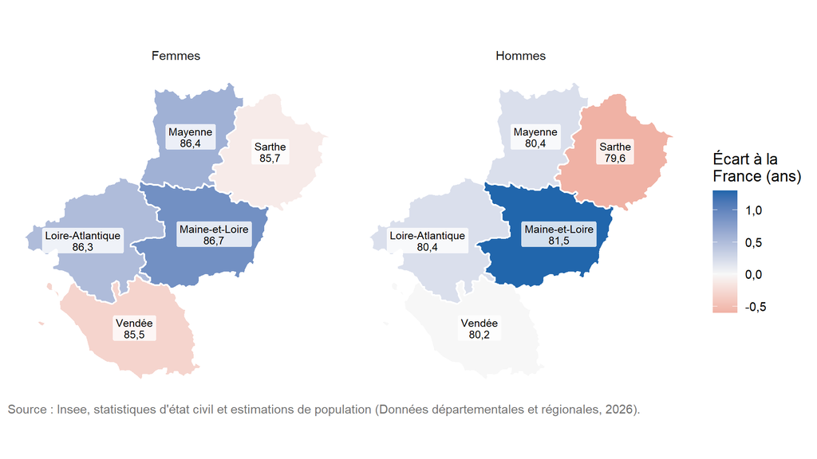

Figure 1: Espérance de vie à la naissance par département en 2024 (étiquettes, en années) et écart à la valeur nationale (couleurs)

```r
carte <- requete("05_carte_departements.sql", annee = annee_ref)

fond <- fond_departements() |>
  filter(code_dep %in% departements_pdl) |>
  left_join(carte, by = "code_dep")

fond_long <- fond |>
  select(nom_dep, esp_vie_femmes, esp_vie_hommes) |>
  pivot_longer(c(esp_vie_femmes, esp_vie_hommes),
               names_to = "sexe", values_to = "ev") |>
  mutate(sexe = ifelse(sexe == "esp_vie_femmes", "Femmes", "Hommes"),
         ref_france = ifelse(sexe == "Femmes", france$esp_vie_femmes,
                             france$esp_vie_hommes),
         ecart = ev - ref_france)

etiquettes <- fond_long |>
  mutate(pt = st_point_on_surface(geometry)) |>
  mutate(x = st_coordinates(pt)[, 1], y = st_coordinates(pt)[, 2])

ggplot(fond_long) +
  geom_sf(aes(fill = ecart), colour = "white", linewidth = 0.6) +
  geom_label(data = st_drop_geometry(etiquettes),
             aes(x, y, label = paste0(nom_dep, "\n", fmt(ev))),
             size = 2.6, label.size = 0, alpha = 0.8, lineheight = 0.9) +
  facet_wrap(~ sexe) +
  scale_fill_gradient2(low = "#d6604d", mid = "#f7f7f7", high = "#2166ac",
                       midpoint = 0, name = "Écart à la\nFrance (ans)",
                       labels = function(x) fmt(x, 1)) +
  labs(caption = source_insee) +
  theme_ors() +
  theme(axis.text = element_blank(), axis.title = element_blank(),
        panel.grid = element_blank(), legend.position = "right")
```

**Voir le code**

```r
ev_f <- arrange(deps, desc(esp_vie_femmes))
ev_h <- arrange(deps, desc(esp_vie_hommes))
```

En 2024, l’espérance de vie des femmes varie de 85,5 ans (Vendée) à 86,7 ans (Maine-et-Loire), soit un écart de 1,2 an. Chez les hommes, elle varie de 79,6 ans (Sarthe) à 81,5 ans (Maine-et-Loire). L’écart entre femmes et hommes atteint 5,7 ans à l’échelle régionale.

## 2.2 Évolution depuis 2010

**Voir le code**

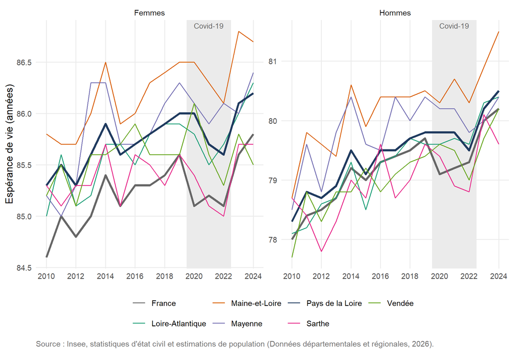

Figure 2: Évolution de l’espérance de vie à la naissance depuis 2010

```r
evol <- requete("02_evolution_esperance_vie.sql", annee_debut = annee_debut) |>
  filter(annee <= annee_ref)

ggplot(evol, aes(annee, esperance_vie, colour = libelle,
                 linewidth = niveau != "departement")) +
  annotate("rect", xmin = 2019.5, xmax = 2022.5, ymin = -Inf, ymax = Inf,
           fill = "grey92") +
  annotate("text", x = 2021, y = Inf, label = "Covid-19", vjust = 1.5,
           size = 3, colour = "grey40") +
  geom_line() +
  facet_wrap(~ sexe, scales = "free_y") +
  scale_colour_manual(values = couleurs_territoires, name = NULL) +
  scale_linewidth_manual(values = c(`FALSE` = 0.5, `TRUE` = 1.2), guide = "none") +
  scale_x_continuous(breaks = seq(annee_debut, annee_ref, 2)) +
  labs(x = NULL, y = "Espérance de vie (années)", caption = source_insee) +
  theme_ors() +
  guides(colour = guide_legend(nrow = 2))
```

**Voir le code**

```r
reg_ev <- filter(evol, code == "52")
v <- function(a, s) reg_ev$esperance_vie[reg_ev$annee == a & reg_ev$sexe == s]
```

Les courbes font apparaître le recul lié à l’épidémie de Covid-19 (2020-2022), puis une reprise. Dans la région, l’espérance de vie des femmes passe de 86,0 ans en 2019 à 86,2 ans en 2024, et celle des hommes de 79,8 à 80,5 ans. À l’échelle d’un département, l’espérance de vie annuelle reste sensible aux fluctuations aléatoires du nombre de décès : les écarts de quelques dixièmes d’année entre deux départements, ou d’une année sur l’autre, doivent être interprétés avec prudence.

# 3 Vieillissement et mortalité : attention au taux brut

**Voir le code**

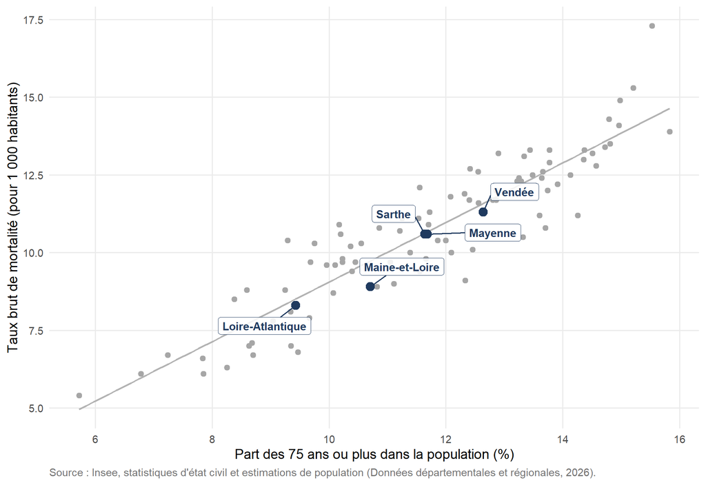

Figure 3: Part des 75 ans ou plus et taux brut de mortalité, départements de France métropolitaine, 2024

```r
vm <- requete("04_vieillissement_mortalite.sql", annee = annee_ref)
correl <- cor(vm$part_75_plus_pct, vm$taux_mortalite_pm)

ggplot(vm, aes(part_75_plus_pct, taux_mortalite_pm)) +
  geom_smooth(method = "lm", se = FALSE, colour = "grey70", linewidth = 0.6) +
  geom_point(data = filter(vm, groupe == "Autres départements"),
             colour = "grey65", size = 1.8) +
  geom_point(data = filter(vm, groupe == "Pays de la Loire"),
             colour = "#1F3A5F", size = 3) +
  ggrepel::geom_label_repel(data = filter(vm, groupe == "Pays de la Loire"),
            aes(label = libelle), colour = "#1F3A5F", size = 3.2,
            fontface = "bold", label.size = 0, fill = alpha("white", 0.85),
            min.segment.length = 0, box.padding = 0.6, seed = 1) +
  labs(x = "Part des 75 ans ou plus dans la population (%)",
       y = "Taux brut de mortalité (pour 1 000 habitants)",
       caption = source_insee) +
  theme_ors()
```

**Voir le code**

```r
pdl_vm <- filter(vm, groupe == "Pays de la Loire") |> arrange(taux_mortalite_pm)
```

Le taux brut de mortalité dépend d’abord de la structure par âge : sur l’ensemble des départements métropolitains, il est très fortement corrélé à la part des 75 ans ou plus (r = 0,91). En 2024, il varie dans la région de 8,3 ‰ en Loire-Atlantique à 11,3 ‰ en Vendée. Cet écart traduit surtout des populations d’âges différents, pas un état de santé différent.

**ImportantPoint de méthode**

Pour comparer la mortalité entre territoires, il faut utiliser un **taux standardisé sur l’âge** (méthode directe, population de référence commune) ou un **indice comparatif de mortalité** (méthode indirecte). Ces calculs demandent les décès par âge et par département, non inclus dans les fichiers utilisés ici. L’espérance de vie, elle, ne dépend pas de la structure par âge : c’est l’indicateur de synthèse le plus adapté pour comparer les départements.

# 4 Mortalité infantile

**Voir le code**

```r
mi <- requete("03_mortalite_infantile_triennale.sql", annee_debut = annee_debut)

# Intervalle de confiance exact à 95 % (loi de Poisson sur le nombre de décès)
ic <- function(d, n, borne) {
  sapply(seq_along(d), function(i) {
    ci <- poisson.test(d[i])$conf.int
    1000 * ci[borne] / n[i]
  })
}
mi <- mi |>
  mutate(ic_bas  = ic(deces_3ans, naissances_3ans, 1),
         ic_haut = ic(deces_3ans, naissances_3ans, 2))

derniere <- filter(mi, annee_fin == max(annee_fin))
```

**Voir le code**

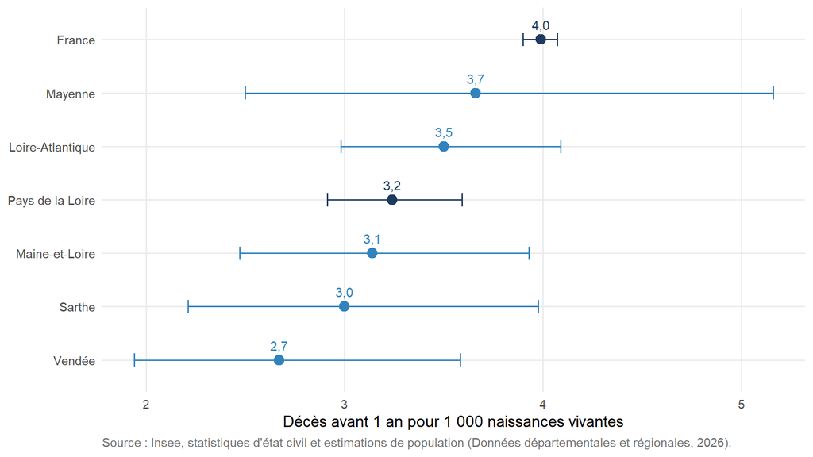

Figure 4: Taux de mortalité infantile sur la période 2022-2024, avec intervalle de confiance à 95 %

```r
derniere |>
  mutate(libelle = reorder(libelle, taux_pour_1000),
         repere = niveau != "departement") |>
  ggplot(aes(taux_pour_1000, libelle, colour = repere)) +
  geom_errorbarh(aes(xmin = ic_bas, xmax = ic_haut), height = 0.25) +
  geom_point(size = 3) +
  geom_text(aes(label = fmt(taux_pour_1000, 1)), vjust = -1, size = 3.2,
            show.legend = FALSE) +
  scale_colour_manual(values = c(`FALSE` = "#3182bd", `TRUE` = "#1F3A5F"),
                      guide = "none") +
  labs(x = "Décès avant 1 an pour 1 000 naissances vivantes", y = NULL,
       caption = source_insee) +
  theme_ors()
```

**Voir le code**

```r
derniere |>
  transmute(Territoire = libelle, `Période` = periode,
            `Décès avant 1 an` = fmtn(deces_3ans),
            `Naissances vivantes` = fmtn(naissances_3ans),
            `Taux (‰)` = fmt(taux_pour_1000, 2),
            `IC à 95 %` = paste0("[", fmt(ic_bas, 2), " ; ", fmt(ic_haut, 2), "]")) |>
  kable(align = "llrrrr")
```

Tableau 2: Effectifs et taux de mortalité infantile, dernière période de 3 ans

| Territoire | Période | Décès avant 1 an | Naissances vivantes | Taux (‰) | IC à 95 % |
| --- | --- | --- | --- | --- | --- |
| Pays de la Loire | 2022-2024 | 360 | 111 123 | 3,24 | [2,91 ; 3,59] |
| Loire-Atlantique | 2022-2024 | 160 | 45 674 | 3,50 | [2,98 ; 4,09] |
| Maine-et-Loire | 2022-2024 | 76 | 24 211 | 3,14 | [2,47 ; 3,93] |
| Mayenne | 2022-2024 | 32 | 8 754 | 3,66 | [2,50 ; 5,16] |
| Sarthe | 2022-2024 | 48 | 16 006 | 3,00 | [2,21 ; 3,98] |
| Vendée | 2022-2024 | 44 | 16 478 | 2,67 | [1,94 ; 3,58] |
| France | 2022-2024 | 8 216 | 2 061 151 | 3,99 | [3,90 ; 4,07] |

**Voir le code**

```r
fr_mi  <- filter(derniere, code == "FR")
reg_mi <- filter(derniere, code == "52")
dep_mi <- filter(derniere, niveau == "departement")
dep_sous_france <- dep_mi$libelle[dep_mi$ic_haut < fr_mi$ic_bas]
region_sous_france <- reg_mi$ic_haut < fr_mi$ic_bas
```

À l’échelle d’un département, la mortalité infantile ne concerne chaque année que quelques dizaines de décès. Un taux annuel serait donc très instable : on cumule ici décès et naissances sur trois ans et on accompagne chaque taux d’un intervalle de confiance exact (loi de Poisson).

# 5 Accès aux soins : les médecins généralistes

**Voir le code**

```r
annee_med <- 2026   # effectifs au 1er janvier, dernière année publiée par la DREES
annee_med_debut <- 2012

med     <- requete("07_medecins_departements.sql",
                   annee = annee_med, annee_debut = annee_med_debut)
med_dep <- filter(med, niveau == "departement")
med_pdl <- filter(med_dep, code_region == "52")
med_reg <- filter(med, code == "52")
med_fm  <- filter(med, code == "FM")

reg_med   <- requete("08_medecins_regions.sql", annee = annee_med)
reg_med_0 <- requete("08_medecins_regions.sql", annee = annee_med_debut)
rang_reg   <- which(reg_med$code_region == "52")
rang_reg_0 <- which(reg_med_0$code_region == "52")

bas  <- slice_min(med_pdl, densite_mg, n = 2)
haut <- slice_max(med_pdl, densite_mg, n = 2)

# Noms avec article, pour des phrases correctes quel que soit le département cité
article <- c("Loire-Atlantique" = "la Loire-Atlantique",
             "Maine-et-Loire" = "le Maine-et-Loire", "Mayenne" = "la Mayenne",
             "Sarthe" = "la Sarthe", "Vendée" = "la Vendée")
avec_art <- function(x) unname(article[x])
majuscule <- function(x) paste0(toupper(substr(x, 1, 1)), substring(x, 2))
fourchette <- function(x) {
  a <- fmt(min(x), 0); b <- fmt(max(x), 0)
  if (a == b) a else paste(a, "à", b)
}
et <- function(x) if (length(x) <= 1) x else
  paste(paste(head(x, -1), collapse = ", "), "et", tail(x, 1))
```

Au 1<sup>er</sup> janvier 2026, les Pays de la Loire comptent **5 646 médecins généralistes**, soit 142 pour 100 000 habitants, contre 146 en France métropolitaine. Depuis 2012, la densité a progressé de 2,1 % dans la région, alors qu’elle a reculé de 6,1 % au niveau national : la région est passée du 12<sup>e</sup> au 8<sup>e</sup> rang des 13 régions métropolitaines.

## 5.1 La région face aux autres régions

**Voir le code**

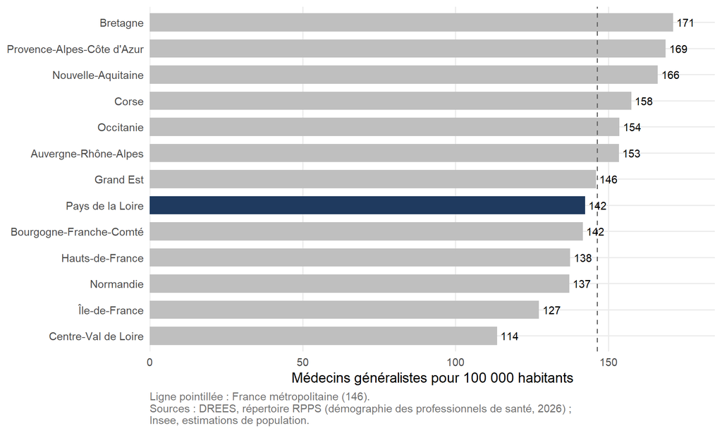

Figure 5: Densité de médecins généralistes par région métropolitaine au 1er janvier 2026

```r
reg_med |>
  mutate(region = reorder(region, densite_mg),
         pdl = code_region == "52") |>
  ggplot(aes(densite_mg, region, fill = pdl)) +
  geom_col(width = 0.7) +
  geom_vline(xintercept = med_fm$densite_mg, linetype = "dashed",
             colour = "grey40") +
  geom_text(aes(label = fmt(densite_mg, 0)), hjust = -0.2, size = 3.1) +
  scale_fill_manual(values = c(`FALSE` = "grey75", `TRUE` = "#1F3A5F"),
                    guide = "none") +
  scale_x_continuous(expand = expansion(mult = c(0, 0.08))) +
  labs(x = "Médecins généralistes pour 100 000 habitants", y = NULL,
       caption = paste0("Ligne pointillée : France métropolitaine (",
                        fmt(med_fm$densite_mg, 0), ").\n", source_drees)) +
  theme_ors()
```

La densité régionale est obtenue en additionnant les généralistes et les habitants des départements de chaque région, puis en divisant. Une moyenne des densités départementales donnerait le même poids à la Lozère qu’au Nord.

## 5.2 Deux profils de départements dans la région

**Voir le code**

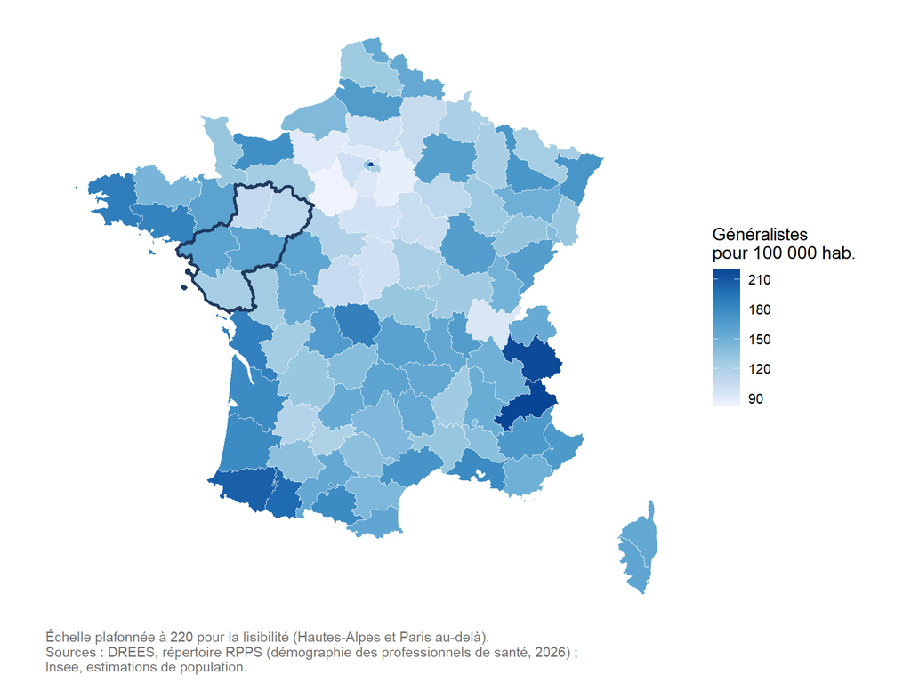

Figure 6: Densité de médecins généralistes par département au 1er janvier 2026, Pays de la Loire en contour

```r
geo_mg <- fond_departements() |>
  left_join(med_dep, by = "code_dep")
contour_pdl <- st_union(filter(geo_mg, code_dep %in% departements_pdl))

ggplot(geo_mg) +
  geom_sf(aes(fill = densite_mg), colour = "white", linewidth = 0.1) +
  geom_sf(data = contour_pdl, fill = NA, colour = "#1F3A5F", linewidth = 0.9) +
  scale_fill_distiller(palette = "Blues", direction = 1,
                       name = "Généralistes\npour 100 000 hab.",
                       limits = c(NA, 220), oob = scales::squish) +
  labs(caption = paste0("Échelle plafonnée à 220 pour la lisibilité ",
                        "(Hautes-Alpes et Paris au-delà).\n", source_drees)) +
  theme_ors() +
  theme(axis.text = element_blank(), panel.grid = element_blank(),
        legend.position = "right")
```

**Voir le code**

```r
med |>
  filter(code_region == "52" | code == "FM") |>
  transmute(
    Territoire = libelle,
    `Généralistes` = fmtn(mg_total),
    `Densité (/100 000)` = fmt(densite_mg, 0),
    `dont libéraux` = fmt(densite_mg_liberal, 0),
    `Rang national` = ifelse(is.na(rang_densite_mg), "",
                             paste0(rang_densite_mg, "/", nb_departements)),
    `Évolution depuis 2012 (%)` = fmt(evolution_densite_pct),
    `60 ans ou plus (%)` = fmt(part_mg_60_plus_pct, 0)
  ) |>
  kable(align = "lrrrrrr")
```

Tableau 3: Médecins généralistes au 1er janvier 2026

| Territoire | Généralistes | Densité (/100 000) | dont libéraux | Rang national | Évolution depuis 2012 (%) | 60 ans ou plus (%) |
| --- | --- | --- | --- | --- | --- | --- |
| Loire-Atlantique | 2 440 | 160 | 96 | 30/101 | 2,8 | 19 |
| Maine-et-Loire | 1 356 | 161 | 96 | 29/101 | 9,1 | 19 |
| Mayenne | 322 | 106 | 53 | 85/101 | -7,9 | 33 |
| Sarthe | 625 | 111 | 56 | 84/101 | -7,8 | 36 |
| Vendée | 903 | 124 | 65 | 75/101 | -0,8 | 31 |
| Pays de la Loire | 5 646 | 142 | 81 |  | 2,1 | 24 |
| France métropolitaine | 97 746 | 146 | 80 |  | -6,1 | 31 |

*Lecture : le rang national classe les 101 départements de la densité la plus élevée (rang 1) à la plus faible. « dont libéraux » : généralistes à exercice exclusivement libéral.*

La région réunit deux situations très différentes. Le Maine-et-Loire et la Loire-Atlantique comptent environ 161 généralistes pour 100 000 habitants, au-dessus de la moyenne nationale ; ce sont les deux départements universitaires de la région (facultés de médecine de Nantes et d’Angers). La Mayenne et la Sarthe en comptent 106 et 111, aux rangs 85 et 84 sur 101. Leur densité a reculé de 7,9 et 7,8 % depuis 2012. Surtout, 33 à 36 % de leurs généralistes ont 60 ans ou plus, contre 19 % dans les deux départements les mieux dotés : de nombreux départs en retraite sont à prévoir là où la densité est déjà la plus faible.

**Voir le code**

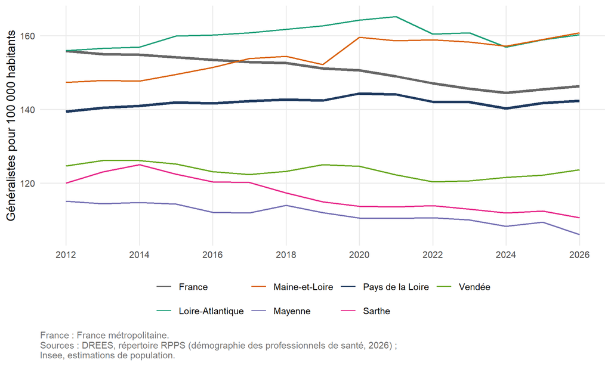

Figure 7: Évolution de la densité de médecins généralistes, 2012-2026

```r
evol_mg <- requete("09_medecins_evolution.sql", annee_debut = annee_med_debut) |>
  mutate(libelle = ifelse(code == "FM", "France", libelle))

ggplot(evol_mg, aes(annee, densite_mg, colour = libelle,
                    linewidth = niveau != "departement")) +
  geom_line() +
  scale_colour_manual(values = couleurs_territoires, name = NULL) +
  scale_linewidth_manual(values = c(`FALSE` = 0.6, `TRUE` = 1.2), guide = "none") +
  scale_x_continuous(breaks = seq(annee_med_debut, annee_med, 2)) +
  labs(x = NULL, y = "Généralistes pour 100 000 habitants",
       caption = paste0("France : France métropolitaine.\n", source_drees)) +
  theme_ors() +
  guides(colour = guide_legend(nrow = 2))
```

## 5.3 Comparaison avec les départements voisins

**Voir le code**

```r
# Départements limitrophes de la région, repérés par la géométrie :
# à moins de 2 km du contour régional (le fond de carte est simplifié,
# les frontières communes ne se touchent pas toujours exactement)
geo_l93    <- st_transform(fond_departements(), 2154)
region_l93 <- st_union(filter(geo_l93, code_dep %in% departements_pdl))
proches    <- lengths(st_is_within_distance(geo_l93, region_l93, dist = 2000)) > 0
voisins    <- setdiff(geo_l93$code_dep[proches], departements_pdl)
```

**Voir le code**

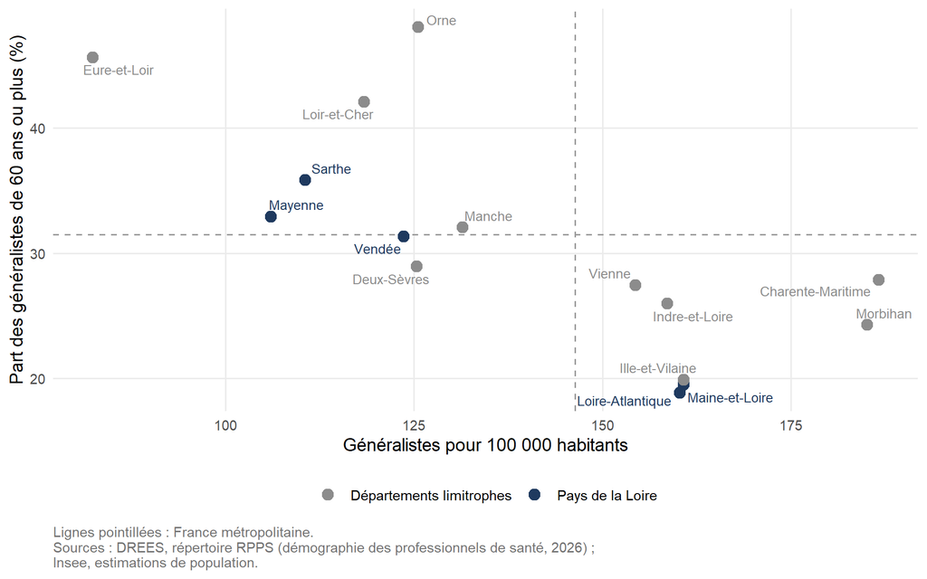

Figure 8: Densité de médecins généralistes et part des 60 ans ou plus, Pays de la Loire et départements limitrophes, 2026

```r
comp <- med_dep |>
  filter(code_dep %in% c(departements_pdl, voisins)) |>
  mutate(groupe = ifelse(code_region == "52", "Pays de la Loire",
                         "Départements limitrophes"))

ggplot(comp, aes(densite_mg, part_mg_60_plus_pct, colour = groupe)) +
  geom_vline(xintercept = med_fm$densite_mg, linetype = "dashed", colour = "grey60") +
  geom_hline(yintercept = med_fm$part_mg_60_plus_pct, linetype = "dashed",
             colour = "grey60") +
  geom_point(size = 3) +
  ggrepel::geom_text_repel(aes(label = libelle), size = 3, seed = 1,
                           show.legend = FALSE) +
  scale_colour_manual(values = c("Pays de la Loire" = "#1F3A5F",
                                 "Départements limitrophes" = "grey55"),
                      name = NULL) +
  labs(x = "Généralistes pour 100 000 habitants",
       y = "Part des généralistes de 60 ans ou plus (%)",
       caption = paste0("Lignes pointillées : France métropolitaine.\n", source_drees)) +
  theme_ors()
```

**Voir le code**

```r
comp_bas <- filter(comp, densite_mg < med_fm$densite_mg,
                   part_mg_60_plus_pct > med_fm$part_mg_60_plus_pct)
```

Les 10 départements limitrophes de la région (Charente-Maritime, Deux-Sèvres, Eure-et-Loir, Ille-et-Vilaine, Indre-et-Loire, Loir-et-Cher, Manche, Morbihan, Orne et Vienne) sont repérés automatiquement à partir du fond de carte. Le graphique croise deux fragilités : une densité faible (à gauche de la ligne verticale) et des généralistes âgés (au-dessus de la ligne horizontale). 6 des 15 départements comparés cumulent les deux. Dans la région, ce sont la Mayenne et la Sarthe. Ils partagent cette situation avec plusieurs de leurs voisins (Eure-et-Loir, Loir-et-Cher, Manche et Orne), plus qu’avec le reste de la région.

**ImportantPoint de méthode**

La densité rapporte un nombre de médecins à une population. Elle **ne mesure pas à elle seule l’accès aux soins** : elle ignore le temps de travail des médecins, leur âge, la distance à parcourir et les besoins d’une population âgée, plus consommatrice de soins. Pour approcher l’accessibilité, la DREES publie l’**APL** (accessibilité potentielle localisée), calculée à l’échelle communale. Par ailleurs, les généralistes comptés ici incluent tous les modes d’exercice (libéral, mixte, salarié) et sont rattachés au lieu de leur activité la plus récente.

# 6 Méthode et reproductibilité

**Données.** Insee, *Données départementales et régionales — État civil et estimations de population* (fichiers DEP1 à DEP5). Les données de la dernière année publiée sont provisoires ; les indicateurs démographiques s’arrêtent donc à 2024. DREES, *La démographie des professionnels de santé depuis 2012* (fichier Médecins, répertoire RPPS) : effectifs au 1<sup>er</sup> janvier, rapportés aux populations Insee au 1<sup>er</sup> janvier (provisoires pour 2026). En 2024, l’extraction du RPPS a été réalisée au 30 septembre et l’activité reconstruite au 1<sup>er</sup> janvier par la DREES.

**Chaîne de traitement.**

1. `R/00_extraire_medecins.R` extrait du fichier DREES (300 000 lignes) les seules lignes utiles dans un petit fichier CSV.
2. `R/01_import_insee.R` lit les fichiers Excel de l’Insee (un onglet par année depuis 1975), ne garde que les lignes de territoires, recode les départements sur les régions actuelles (les fichiers antérieurs à 2015 utilisent les anciennes régions) et charge le tout dans une base SQLite. Des contrôles arrêtent le script en cas d’incohérence : somme des départements égale au total régional, nombre de départements constant, densités de généralistes identiques à celles publiées par la DREES.
3. Les indicateurs sont calculés en SQL (dossier `sql/`) : jointures, fonctions de fenêtre pour les rangs nationaux et les cumuls sur 3 ans.
4. Ce rapport Quarto et l’application Shiny interrogent la même base : une mise à jour des fichiers sources met à jour toutes les restitutions.

**Limites.** Les taux bruts ne sont pas standardisés sur l’âge ; les petits effectifs (mortalité infantile, petits départements) imposent des regroupements pluriannuels et une lecture prudente des écarts ; la densité de médecins n’est qu’une première approche de l’accès aux soins.